# Taller 1

Diego Alberto Rodríguez Cruz - Maestria en Matemáticas Aplicadas y Ciencias de la Computación

2023-03-28

# Dependencias

- ´install.packages(“corrplot”)´
- ´install.packages(“readr”)´
- ´install.packages(“ggplot2”)´
- ´install.packages(“dplyr”)´
- ´install.packages(“ggbiplot”)´
- ´install.packages(“dendextend”)´
- ´install.packages(“crosstable”)´
- ´install.packages(“purrr”)´
- ´install.packages(“cluster”)´
- ´install.packages(“glmnet”)´
- ´install.packages(“car”)´
- ´install.packages(“tidyr”)´
- ´install.packages(“tibble”)´

# Librerías

```r
library(corrplot)
library(readr)
library(ggplot2)
library(dplyr)
library(ggbiplot)
library(dendextend)
library(crosstable)
library(purrr)
library(cluster)
library(glmnet)
library(Metrics)
library(car)
library(tidyr)
library(tibble)
```

# Problema

El conjunto de datos taller1.txt contiene la información del perfíl genómico de un conjunto de 1200 líneas celulares. Para estas se busca determinar cuáles de los 5000 genes (ubicados en cada columna) son de relevancia para la predicción de la variable respuesta (efectividad del tratamiento anticancer, medida como variable continua).

```r
# Carga de datos
data <- read.delim2(file="taller1.txt", header=TRUE, sep = ",", dec = ".")

head(data,10) #Mostrar los primeros 10 registros
```

[output not shown]

[output cut: 9148 more lines]

Responda las siguientes preguntas:

## P1

¿Hay multicolinealidad en los datos?

```r
# Correlación
#cor(data)
mat_cor <- data %>% cor(method="pearson") %>% round(digits=2)
#Matriz de correlación
mat_cor
```

[output not shown]

[output cut: 8286 more lines]

[output not shown]

```r
# Cálculo de la determinante de la matriz de correlación
det(mat_cor)
```

```
## [1] 0
```

- La determinante de la matriz da 0, lo que significa que existe una multicolinealidad perfecta del conjunto de datos suministrado. Existe más columnas/variables (5000) que registros (1200), lo cual genera una multicolinealidad perfecta entre las variables.

## P2

Separe aleatoriamente (pero guarde la semilla) su conjunto de datos en dos partes:

- Entrenamiento: 1000 líneas celulares
- Prueba: 200 líneas celulares

```r
set.seed(123)

x <- data.frame(data[,2:5001]) # Se elimina la variable Y
y <- data$y

dataSplit <- sample(nrow(x),
                    size=nrow(x)*0.834,
                    replace = FALSE)

# separar los datos entramiento y prueba
train_x <- x[dataSplit, ]
test_x <- x[-dataSplit, ]
train_y <- y[dataSplit]
test_y <- y[-dataSplit]


train_x <- scale(train_x)
test_x <- scale(test_x)
train_y <- scale(train_y)
test_y <- scale(test_y)
```

```r
cat("Entrenamiento: ", nrow(train_x),"\n")
```

```
## Entrenamiento:  1000
```

```r
cat("Prueba: ", nrow(test_x),"\n")
```

```
## Prueba:  200
```

## P3

Usando los 1000 datos de entrenamiento, determine los valores de $\lambda_r$ y $\lambda_l$ de regresión Ridge y Lasso, respectivamente, que minimicen el Error Cuadrático Medio (ECM) mediante validación externa. Utilice el método de validación externa que considere más apropiado.

### Ridge

```r
set.seed(123)

ridge <- glmnet::glmnet(train_x, train_y, alpha = 0)
```

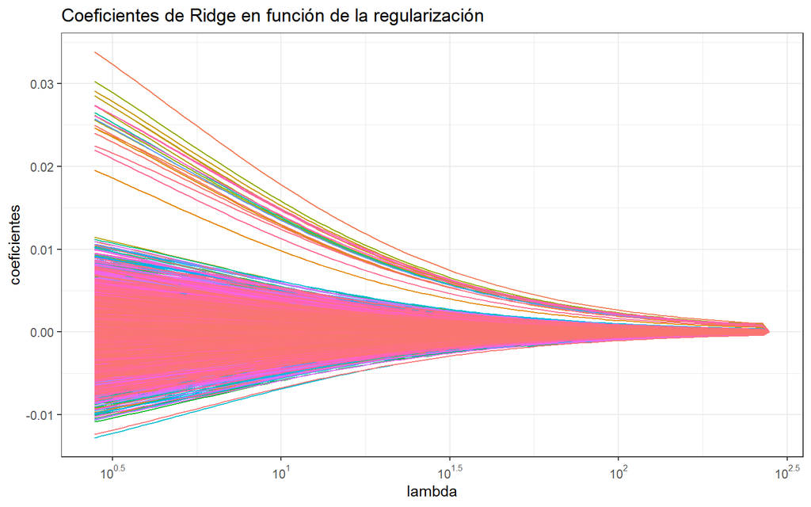

```r
set.seed(123)
# Evolución de los coeficientes en función de lambda
# ==============================================================================
regularizacion_r <- ridge$beta %>%
                  as.matrix() %>%
                  t() %>%
                  as_tibble() %>%
                  mutate(lambda = ridge$lambda)

regularizacion_r <- regularizacion_r %>%
                   pivot_longer(
                     cols = !lambda,
                     names_to = "predictor",
                     values_to = "coeficientes"
                   )

regularizacion_r %>%
  ggplot(aes(x = lambda, y = coeficientes, color = predictor)) +
  geom_line() +
  scale_x_log10(
    breaks = trans_breaks("log10", function(x) 10^x),
    labels = trans_format("log10", math_format(10^.x))
  ) +
  labs(title = "Coeficientes de Ridge en función de la regularización") +
  theme_bw() +
  theme(legend.position = "none")
```

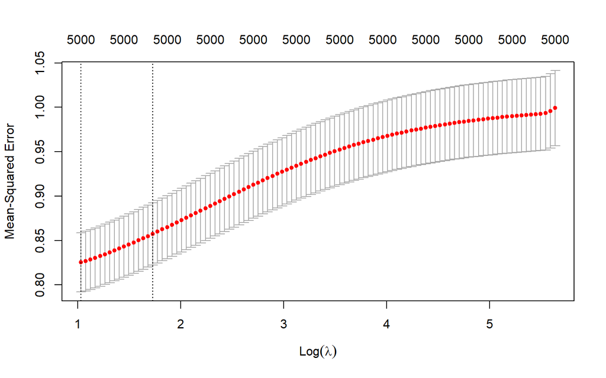

```r
set.seed(123)
cv_error_r <- glmnet::cv.glmnet(train_x,train_y, alpha  = 0)

# ECM para Ridge
plot(cv_error_r)
```

```r
cat("Ridge: Mejor Lambda encontrado = " , cv_error_r$lambda.min, "\n")
```

```
## Ridge: Mejor Lambda encontrado =  2.802319
```

```r
cat("Ridge: Mejor valor de lambda encontrado + 1 desviación estándar:", cv_error_r$lambda.1se, "\n")
```

```
## Ridge: Mejor valor de lambda encontrado + 1 desviación estándar: 5.630512
```

### Lasso

```r
set.seed(123)
lasso <- glmnet::glmnet(train_x, train_y, alpha = 1)
```

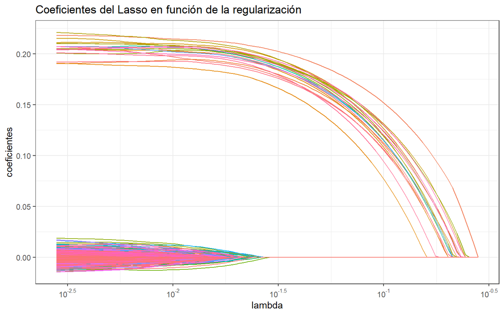

```r
set.seed(123)
# Evolución de los coeficientes en función de lambda
# ==============================================================================
regularizacion_l <- lasso$beta %>%
                  as.matrix() %>%
                  t() %>%
                  as_tibble() %>%
                  mutate(lambda = lasso$lambda)

regularizacion_l <- regularizacion_l %>%
                   pivot_longer(
                     cols = !lambda,
                     names_to = "predictor",
                     values_to = "coeficientes"
                   )

regularizacion_l %>%
  ggplot(aes(x = lambda, y = coeficientes, color = predictor)) +
  geom_line() +
  scale_x_log10(
    breaks = trans_breaks("log10", function(x) 10^x),
    labels = trans_format("log10", math_format(10^.x))
  ) +
  labs(title = "Coeficientes del Lasso en función de la regularización") +
  theme_bw() +
  theme(legend.position = "none")
```

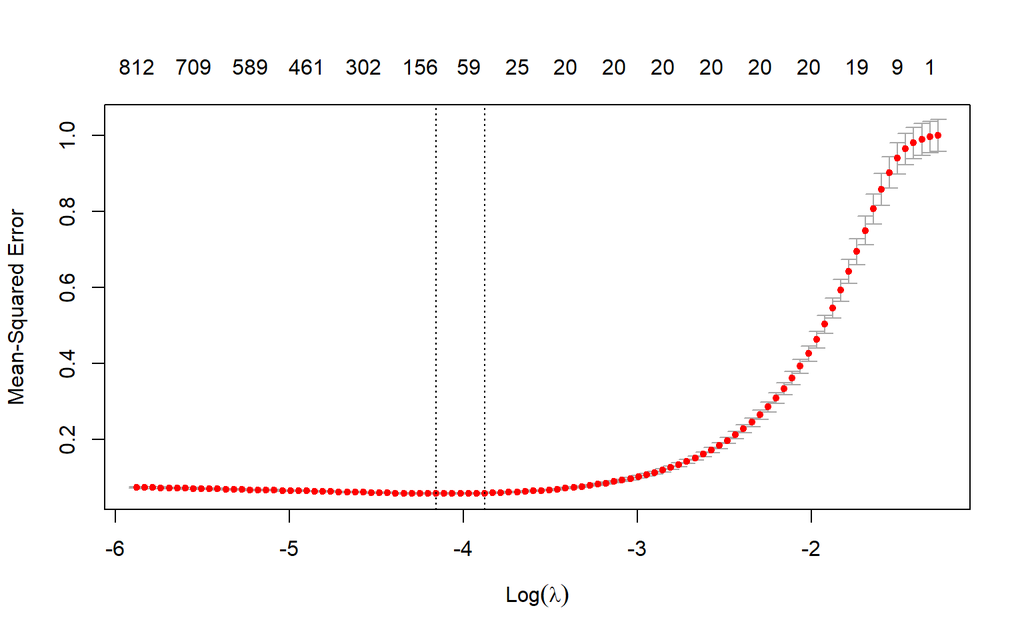

```r
set.seed(123)
cv_error_l <- glmnet::cv.glmnet(train_x,train_y, alpha  = 1)

# ECM para Ridge
plot(cv_error_l)
```

```r
cat("Lasso: Mejor Lambda encontrado = " , cv_error_l$lambda.min, "\n")
```

```
## Lasso: Mejor Lambda encontrado =  0.01566723
```

```r
cat("Lasso: Mejor valor de lambda encontrado + 1 desviación estándar:", cv_error_l$lambda.1se, "\n")
```

```
## Lasso: Mejor valor de lambda encontrado + 1 desviación estándar: 0.02071116
```

## P4

Ajuste la regresión Ridge y Lasso con los valores estimados de $\lambda_r$ y $\lambda_l$ obtenidos en (3) usando los 1000 datos de entrenamiento.

### Ridge

```r
set.seed(123)

ridge_n2 <- glmnet::glmnet(
  train_x,
  train_y,
  alpha = 0,
  lambda = cv_error_r$lambda.1se)
```

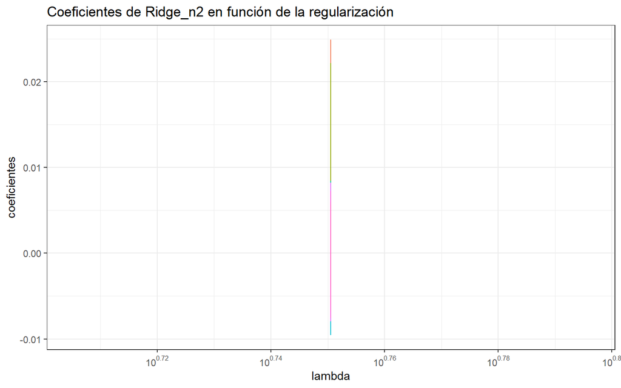

```r
set.seed(123)
# Evolución de los coeficientes en función de lambda
# ==============================================================================
regularizacion_r2 <- ridge_n2$beta %>%
                  as.matrix() %>%
                  t() %>%
                  as_tibble() %>%
                  mutate(lambda = ridge_n2$lambda)

regularizacion_r2 <- regularizacion_r2 %>%
                   pivot_longer(
                     cols = !lambda,
                     names_to = "predictor",
                     values_to = "coeficientes"
                   )

regularizacion_r2 %>%
  ggplot(aes(x = lambda, y = coeficientes, color = predictor, group=1)) +
  geom_line() +
  scale_x_log10(
    breaks = trans_breaks("log10", function(x) 10^x),
    labels = trans_format("log10", math_format(10^.x))
  ) +
  labs(title = "Coeficientes de Ridge_n2 en función de la regularización") +
  theme_bw() +
  theme(legend.position = "none")
```

### Lasso

```r
set.seed(123)

lasso_n2 <- glmnet::glmnet(
  train_x,
  train_y,
  alpha = 1,
  lambda = cv_error_l$lambda.1se)
```

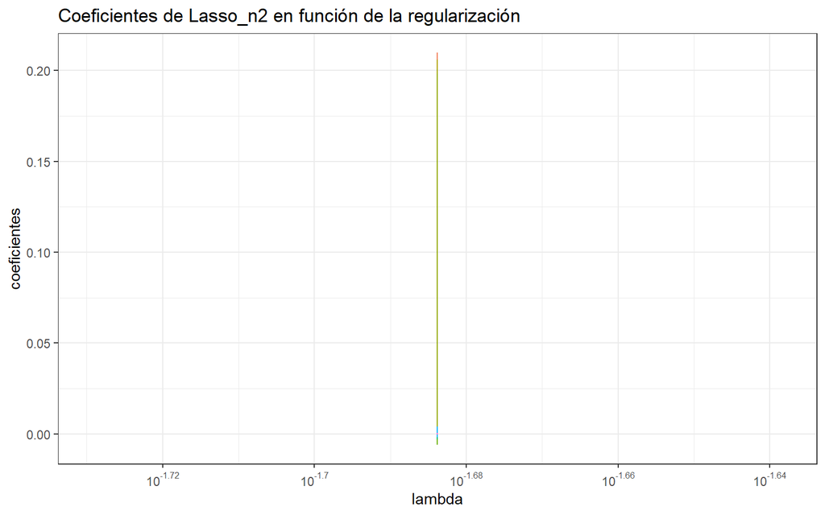

```r
set.seed(123)
# Evolución de los coeficientes en función de lambda
# ==============================================================================
regularizacion_l2 <- lasso_n2$beta %>%
                  as.matrix() %>%
                  t() %>%
                  as_tibble() %>%
                  mutate(lambda = lasso_n2$lambda)

regularizacion_l2 <- regularizacion_l2 %>%
                   pivot_longer(
                     cols = !lambda,
                     names_to = "predictor",
                     values_to = "coeficientes"
                   )

regularizacion_l2 %>%
  ggplot(aes(x = lambda, y = coeficientes, color = predictor, group=1)) +
  geom_line() +
  scale_x_log10(
    breaks = trans_breaks("log10", function(x) 10^x),
    labels = trans_format("log10", math_format(10^.x))
  ) +
  labs(title = "Coeficientes de Lasso_n2 en función de la regularización") +
  theme_bw() +
  theme(legend.position = "none")
```

## P5

Para los modelos ajustados en (4) determine el más apropiado para propósitos de predicción. Considere unicamente el ECM en los 200 datos de prueba para su decisión.

### Ridge

#### Entrenamiento

```r
set.seed(123)
predicciones_train_r <- predict(ridge_n2, newx = train_x)
```

```r
set.seed(123)
training_mse_r <- mean((predicciones_train_r - train_y)^2)
cat("Ridge - Error (MSE/ECM) de entrenamiento:", training_mse_r)
```

```
## Ridge - Error (MSE/ECM) de entrenamiento: 0.2616762
```

#### Prueba

```r
set.seed(123)
predicciones_test_r <- predict(ridge_n2, newx = test_x)
```

```r
set.seed(123)
test_mse_ridge <- mean((predicciones_test_r - test_y)^2)
paste("Ridge - Error (MSE/ECM) de test:", test_mse_ridge)
```

```
## [1] "Ridge - Error (MSE/ECM) de test: 0.902754245809342"
```

### Lasso

#### Entrenamiento

```r
set.seed(123)
predicciones_train_l <- predict(lasso_n2, newx = train_x)
```

```r
set.seed(123)
training_mse_l <- mean((predicciones_train_l - train_y)^2)
cat("Lasso - Error (MSE/ECM) de entrenamiento:", training_mse_l)
```

```
## Lasso - Error (MSE/ECM) de entrenamiento: 0.05383313
```

#### Prueba

```r
set.seed(123)
predicciones_test_l <- predict(lasso_n2, newx = test_x)
```

```r
set.seed(123)
test_mse_lasso <- mean((predicciones_test_l - test_y)^2)
paste("Lasso - Error (MSE/ECM) de test:", test_mse_lasso)
```

```
## [1] "Lasso - Error (MSE/ECM) de test: 0.10164397131895"
```

## P6

Ajuste el modelo seleccionado en (5) para los 1200 datos. Note que en este punto ya tiene un $\lambda$ estimado y un modelo seleccionado.

### Ridge

```r
set.seed(123)

ridge_full <- glmnet::glmnet(
  x,
  y,
  alpha = 0,
  lambda = cv_error_r$lambda.1se)
```

#### Entrenamiento

```r
set.seed(123)
predicciones_train_rf <- predict(ridge_full, newx = train_x)
```

```r
set.seed(123)
training_mse_rf <- mean((predicciones_train_rf - train_y)^2)
paste("Ridge - Error (MSE/ECM) de test:", training_mse_rf)
```

```
## [1] "Ridge - Error (MSE/ECM) de test: 6.77430293286469"
```

#### Prueba

```r
set.seed(123)
predicciones_test_rf <- predict(ridge_full, newx = test_x)
```

```r
set.seed(123)
test_mse_ridge_rf <- mean((predicciones_test_rf - test_y)^2)
paste("Ridge - Error (MSE/ECM) de test:", test_mse_ridge_rf)
```

```
## [1] "Ridge - Error (MSE/ECM) de test: 4.75767056933362"
```

```r
set.seed(123)

lasso_full <- glmnet::glmnet(
  x,
  y,
  alpha = 0,
  lambda = cv_error_l$lambda.1se)
```

#### Entrenamiento

```r
set.seed(123)
predicciones_train_lf <- predict(lasso_full, newx = train_x)
```

```r
set.seed(123)
training_mse_lf <- mean((predicciones_train_lf - train_y)^2)
cat("Lasso - Error (MSE/ECM) de entrenamiento:", training_mse_lf)
```

```
## Lasso - Error (MSE/ECM) de entrenamiento: 12.84163
```

#### Prueba

```r
set.seed(123)
predicciones_test_lf <- predict(lasso_full, newx = test_x)
```

```r
set.seed(123)
test_mse_lasso_f <- mean((predicciones_test_lf - test_y)^2)
paste("Lasso - Error (MSE/ECM) de test:", test_mse_lasso_f)
```

```
## [1] "Lasso - Error (MSE/ECM) de test: 9.49382740598837"
```

## P7

Grafique las trazas de los coeficientes en función de la penalización para el modelo ajustado en (6).

### Ridge

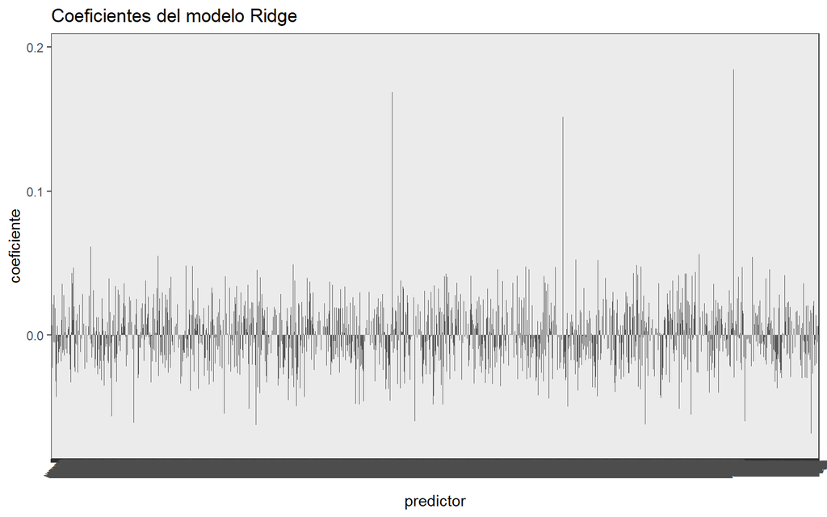

```r
set.seed(123)

# Coeficientes del modelo Ridge con los 1200 registros
df_coeficientes_rf <- coef(ridge_full) %>%
                   as.matrix() %>%
                   as_tibble(rownames = "predictor") %>%
                   dplyr::rename(coeficiente = s0)

df_coeficientes_rf %>%
  filter(predictor != "(Intercept)") %>%
  ggplot(aes(x = predictor, y = coeficiente)) +
  geom_col() +
  labs(title = "Coeficientes del modelo Ridge") +
  theme_bw() +
  theme(axis.text.x = element_text(size = 6, angle = 45))
```

```r
set.seed(123)
df_coeficientes_rf %>%
  filter(
    predictor != "(Intercept)",
    coeficiente != 0
)
```

```
## # A tibble: 5,000 × 2
##    predictor coeficiente
##    <chr>           <dbl>
##  1 V1              0.145
##  2 V2              0.174
##  3 V3              0.169
##  4 V4              0.152
##  5 V5              0.184
##  6 V6              0.184
##  7 V7              0.179
##  8 V8              0.156
##  9 V9              0.156
## 10 V10             0.150
## # ℹ 4,990 more rows
```

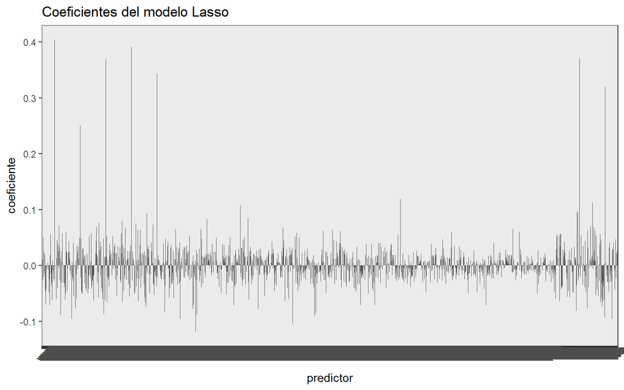

```r
set.seed(123)

# Coeficientes del modelo Lasso con los 1200 registros
df_coeficientes_lf <- coef(lasso_full) %>%
                   as.matrix() %>%
                   as_tibble(rownames = "predictor") %>%
                   dplyr::rename(coeficiente = s0)

df_coeficientes_lf %>%
  filter(predictor != "(Intercept)") %>%
  ggplot(aes(x = predictor, y = coeficiente)) +
  geom_col() +
  labs(title = "Coeficientes del modelo Lasso") +
  theme_bw() +
  theme(axis.text.x = element_text(size = 6, angle = 45))
```

```r
set.seed(123)
df_coeficientes_lf %>%
  filter(
    predictor != "(Intercept)",
    coeficiente != 0
)
```

```
## # A tibble: 5,000 × 2
##    predictor coeficiente
##    <chr>           <dbl>
##  1 V1              0.292
##  2 V2              0.345
##  3 V3              0.326
##  4 V4              0.318
##  5 V5              0.377
##  6 V6              0.376
##  7 V7              0.371
##  8 V8              0.312
##  9 V9              0.320
## 10 V10             0.290
## # ℹ 4,990 more rows
```

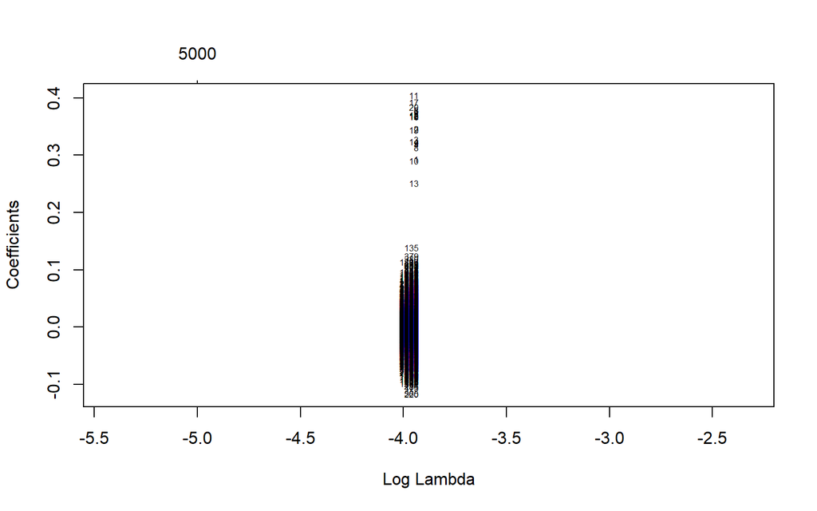

```r
plot(lasso_full, xvar = "lambda", label = TRUE)
```

## P8

En un párrafo resuma los resultados obtenidos dado el objetivo inicial del estudio.

**R:/** De acuerdo a los resultados obtenidos previamente, se evidencia:

1. El modelo Lasso contiene mejores $\lambda$ que el modelo Ridge
2. El modelo Lasso presenta menor ECM (Error Cuadratico Medio), lo que lo hace mejor para los datos suministrados.
3. Se evidencia que los datos presentan multicolinealidad perfecta dado el números de registros vs variables.